# Time series Analysis

Egg depositions of Lake Huron Bloasters

Yiding Carson

# Introduction

The task of the study is to analyze the egg depositions of Lake Huron Bloasters between years 1981 to 1996, then find the best fitted model to give forecasts of egg depositions in the next 5 years.

# Method

## Reading and converting the data.

The original data has been imported to Rstudio for further study.After visualizing the raw data,the five main characteristics of the egg depositions sereies are indicated as in Fig.1.  
- Trend:A general climbing trend with some violent fluctuations.  
- Seasonality:Not obvious.  
- Interventions:Not obvious.  
- changing variance:There seems to be changing variance.  
- Behaviour:An overall non-stationarity behaviour with non-constant mean was observed in the egg depositions series.Also,the autoregressive as well as moving average behaviour were observed.

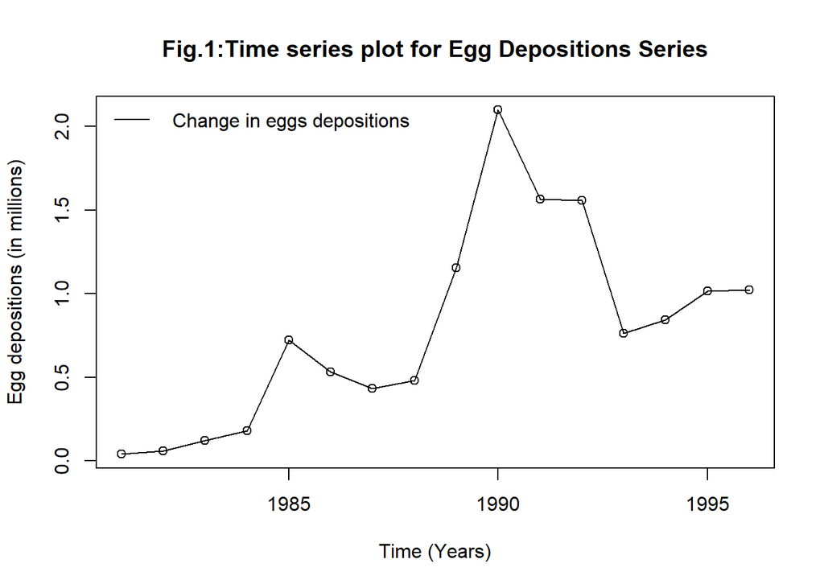

```r
#read the file in R
eggs <- read.csv("D:/Time series anlytic/Assignment 2/eggs.csv")
#Convert the dataset format to time series format
rownames(eggs)<-seq(from=1981, to=1996)
eggsdata=ts(as.vector(eggs['eggs']), start=1981, end=1996)
#Plot the time series with legend.
plot(eggs,type='o',ylab='Egg depositions (in millions)',xlab='Time (Years)',main = "Fig.1:Time series plot for Egg Depositions Series")
legend( "topleft",lty=1, bty = "n" ,text.width = 12, c(" Change in eggs depositions"))
```

Since the non-stationarity and the non-seasonality of the egg depositions series,the study applied two simple model (linear model and quadratic model) to investigate their fitness to the series first.If they can not fit the trend well,the ARIMA model will be used to explore its best fitted coefficient and give forcasts to the eggs depositions in the next 5 years.

## Linear model

The Linear model plot for egg depositions series(Fig.2) was shown below,the linear trend in the gragh does not fit the overall changes in eggs depositions well.In additon, although the slope and the intercept of its linear regression model are statistically significant(p=0.005), the R^2 statistic reaveals only 40% of the changes in egg depositions were determined by the linear model which is much less than expected 80%.Overall,the linear model is not an ideal model for the egg depositions series and leaves further analysis of the linear model unnecessary.

```r
lmodel<-lm(eggsdata~time(eggsdata))
summary(lmodel)
```

```
##
## Call:
## lm(formula = eggsdata ~ time(eggsdata))
##
## Residuals:
##     Min      1Q  Median      3Q     Max
## -0.4048 -0.2768 -0.1933  0.2536  1.1857
##
## Coefficients:
##                  Estimate Std. Error t value Pr(>|t|)
## (Intercept)    -165.98275   49.58836  -3.347  0.00479 **
## time(eggsdata)    0.08387    0.02494   3.363  0.00464 **
## ---
## Signif. codes:  0 '***' 0.001 '**' 0.01 '*' 0.05 '.' 0.1 ' ' 1
##
## Residual standard error: 0.4598 on 14 degrees of freedom
## Multiple R-squared:  0.4469, Adjusted R-squared:  0.4074
## F-statistic: 11.31 on 1 and 14 DF,  p-value: 0.004642
```

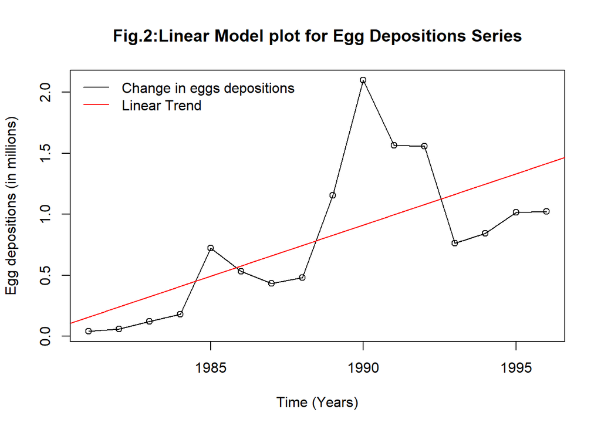

```r
plot(eggs,type='o',ylab='Egg depositions (in millions)',xlab='Time (Years)',main = "Fig.2:Linear Model plot for Egg Depositions Series")
abline(lmodel,col='red',lty=1) # add the fitted least squares line from model1
legend( "topleft",col=c("black","red"),lty=1, bty = "n" ,text.width = 12, c("Change in eggs depositions","Linear Trend"))
```

## Quadratic Model

The curve of quadratic model in Fig.3 seems to fit the changes in eggs depositions better,while the slope and the intercept of the quadratic regression model are statistically significant(p<0.05).However,the R-square statistic shows only 53% of the trend is explained by the quadratic model which is also much smaller than expected 80%.Above all,both linear model and quadratic model are not ideal solutions to forcast eggs depotitions series.

```r
t = time(eggsdata)
t2 = t^2
qmodel = lm(eggsdata~ t + t2) # label the quadratic trend model as qmodel
summary(qmodel)
```

```
##
## Call:
## lm(formula = eggsdata ~ t + t2)
##
## Residuals:
##      Min       1Q   Median       3Q      Max
## -0.50896 -0.25523 -0.02701  0.16615  0.96322
##
## Coefficients:
##               Estimate Std. Error t value Pr(>|t|)
## (Intercept) -4.647e+04  2.141e+04  -2.170   0.0491 *
## t            4.665e+01  2.153e+01   2.166   0.0494 *
## t2          -1.171e-02  5.415e-03  -2.163   0.0498 *
## ---
## Signif. codes:  0 '***' 0.001 '**' 0.01 '*' 0.05 '.' 0.1 ' ' 1
##
## Residual standard error: 0.4092 on 13 degrees of freedom
## Multiple R-squared:  0.5932, Adjusted R-squared:  0.5306
## F-statistic: 9.479 on 2 and 13 DF,  p-value: 0.00289
```

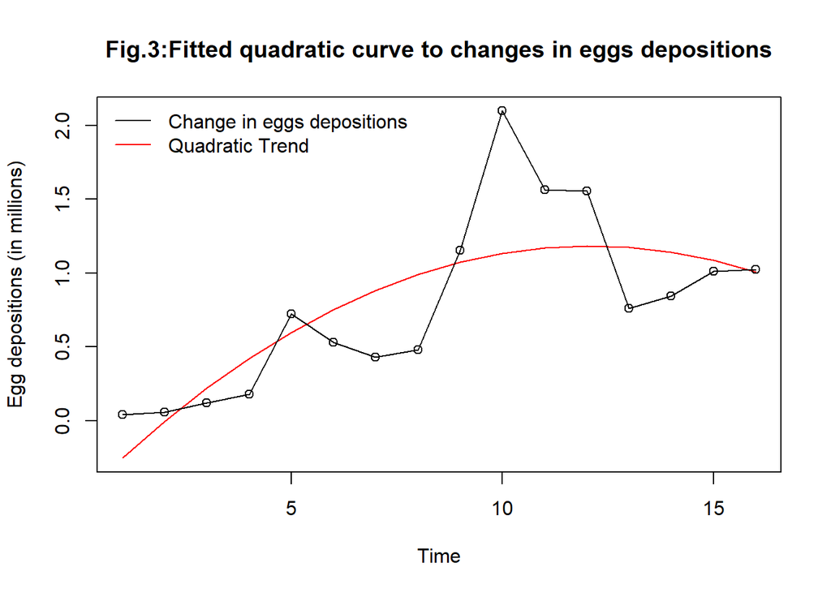

```r
plot(ts(fitted(qmodel)), ylim=c(min(c(fitted(qmodel),as.vector(eggsdata))),max(c(fitted(qmodel),as.vector(eggsdata)))),col=c('red'), ylab='Egg depositions (in millions)',xlab='Time',main = "Fig.3:Fitted quadratic curve to changes in eggs depositions")
lines(as.vector(eggsdata),type="o")
legend ("topleft", lty = 1,bty="n", col = c("black","red"),text.width = 25,c("Change in eggs depositions","Quadratic Trend"))
```

## ARIMA Model

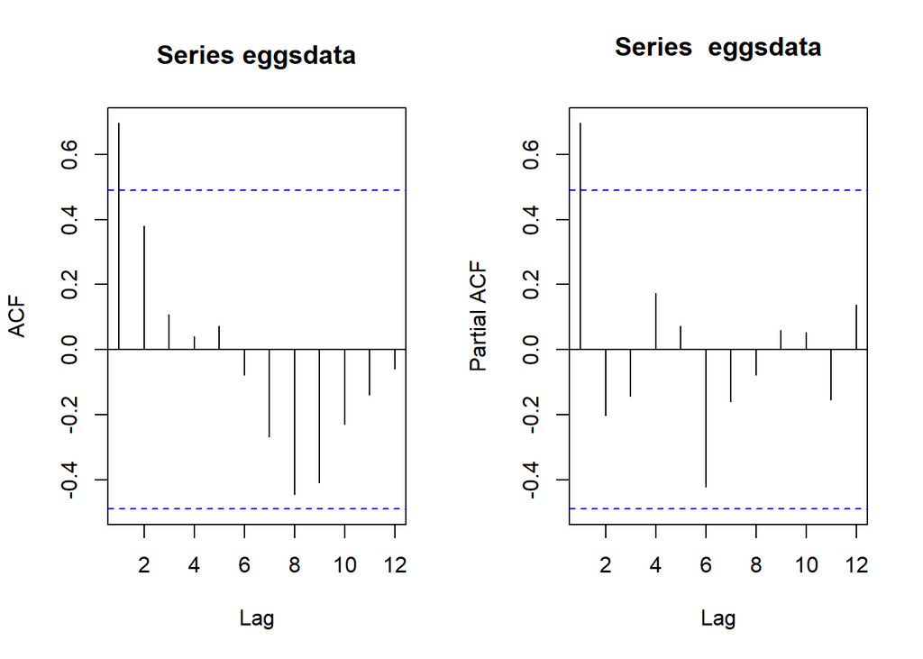

```r
par(mfrow=c(1,2))
acf(eggsdata)
pacf(eggsdata)
```

```r
adf.test(eggsdata)
```

```
##
##  Augmented Dickey-Fuller Test
##
## data:  eggsdata
## Dickey-Fuller = -2.0669, Lag order = 2, p-value = 0.5469
## alternative hypothesis: stationary
```

### Boxcox transformation

```r
eggsdata.T = BoxCox.ar(eggsdata, method='yule-walker')
```

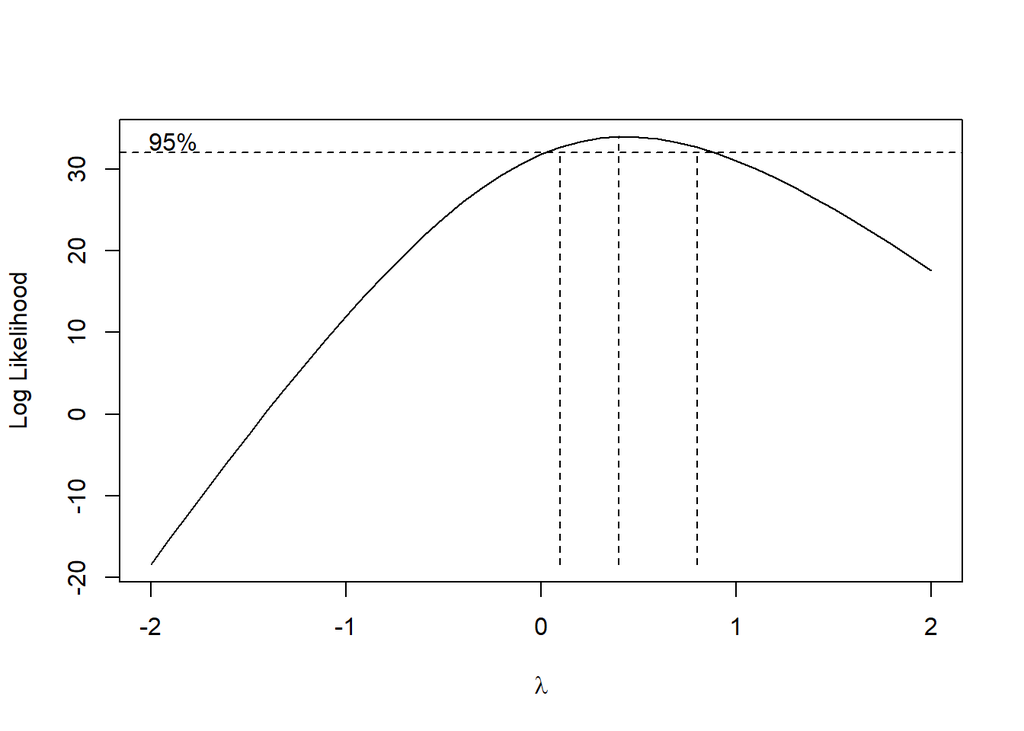

```r
eggsdata.T$ci #Confident Interval
```

```
## [1] 0.1 0.8
```

```r
lambda=0.45 #Middle value of the Confident Interval
eggsdata.BC = (eggsdata^lambda-1)/lambda #Apply the Boxcox Transformation
```

#### Normality check in Boxcox Transformation

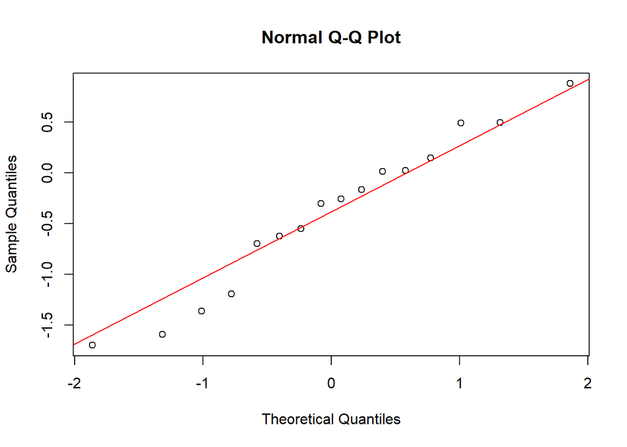

```r
par(mfrow=c(1,1))
qqnorm(eggsdata.BC)
qqline(eggsdata.BC, col = 2)
```

```r
shapiro.test(eggsdata.BC)
```

```
##
##  Shapiro-Wilk normality test
##
## data:  eggsdata.BC
## W = 0.96269, p-value = 0.7107
```

### First Differencing

After differencing the eggs depositions series once,we can accept its stationarity according to the ADF test(p<0.05).Next,the study will find the possible coefficients in the ARIMA(p,1,q) model.

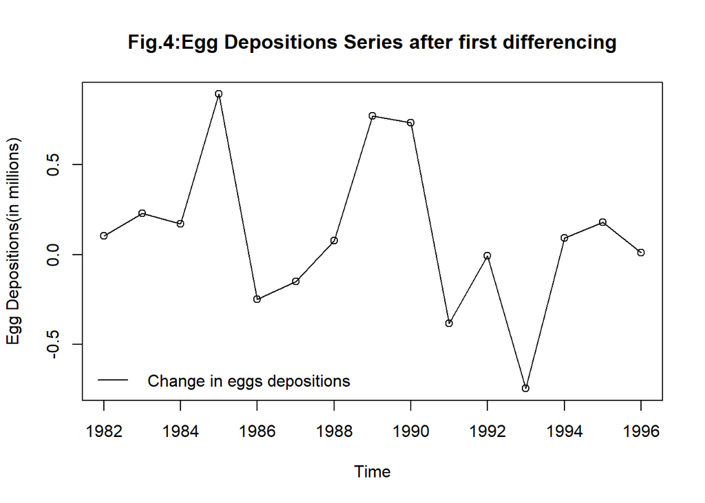

```r
eggsdata.D1=diff(eggsdata.BC)
plot(eggsdata.D1,type='o',ylab='Egg Depositions(in millions)',main = "Fig.4:Egg Depositions Series after first differencing")
legend( "bottomleft",lty=1, bty = "n" ,text.width = 12, c(" Change in eggs depositions"))
```

```r
adf.test(eggsdata.D1)
```

```
##
##  Augmented Dickey-Fuller Test
##
## data:  eggsdata.D1
## Dickey-Fuller = -3.6798, Lag order = 2, p-value = 0.0443
## alternative hypothesis: stationary
```

### Possible ARIMA models

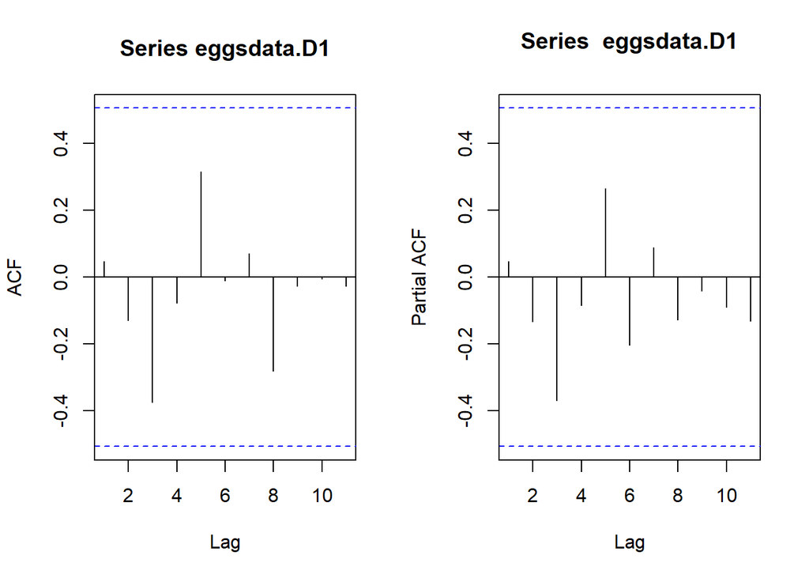

```r
par(mfrow=c(1,2))
acf(eggsdata.D1)
pacf(eggsdata.D1)
```

The possible candidates observed from eacf table are (1,1,1),(1,1,0),(0,1,1).

```r
eacf(eggsdata.D1,ar.max = 3, ma.max = 3)
```

```
## AR/MA
##   0 1 2 3
## 0 o o o o
## 1 o o o o
## 2 o o o o
## 3 o o o o
```

From the BIC table we can only add (3,1,0) as a likely candidate.

```r
res = armasubsets(y=eggsdata.D1,nar=4,nma=4,y.name='test',ar.method='yule-walker')
```

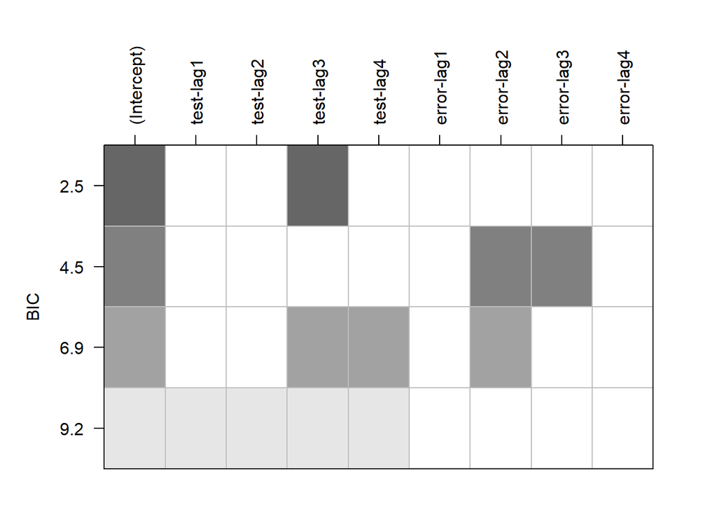

```r
plot(res)
```

above,we found four possible candidates to forcast the eggs depositions series which are (1,1,1),(1,1,0),(0,1,1) and (3,1,0).Next,the study will find the parameter estimation of each possible candidates using conditional sum of squares (CSS) and the maximum likelihood estimation (ML) methods.

### Parameter Estimation of ARIMA model

```r
#CSS
model_011_css = arima(eggsdata.BC,order=c(0,1,1),method='CSS')
coeftest(model_011_css)
```

```
##
## z test of coefficients:
##
##     Estimate Std. Error z value Pr(>|z|)
## ma1  0.11857    0.24784  0.4784   0.6324
```

```r
#ML
model_011_ml = arima(eggsdata.BC,order=c(0,1,1),method='ML')
coeftest(model_011_ml)
```

```
##
## z test of coefficients:
##
##     Estimate Std. Error z value Pr(>|z|)
## ma1  0.11173    0.24186   0.462   0.6441
```

- ARIMA(1,1,0)

```r
#CSS
model_110_css = arima(eggsdata.BC,order=c(1,1,0),method='CSS')
coeftest(model_011_css)
```

[output not shown]

```r
#ML
model_110_ml = arima(eggsdata.BC,order=c(1,1,0),method='ML')
coeftest(model_011_ml)
```

[output not shown]

- ARIMA(1,1,1)

```r
#CSS
model_111_css = arima(eggsdata.BC,order=c(1,1,1),method='CSS')
coeftest(model_011_css)
```

[output not shown]

```r
#ML
model_111_ml = arima(eggsdata.BC,order=c(1,1,1),method='ML')
coeftest(model_011_ml)
```

[output not shown]

- ARIMA(3,1,0)

```r
#CSS
model_310_css = arima(eggsdata.BC,order=c(3,1,0),method='CSS')
coeftest(model_011_css)
```

[output not shown]

```r
#ML
model_310_ml = arima(eggsdata.BC,order=c(3,1,0),method='ML')
coeftest(model_011_ml)
```

[output not shown]

### Sorting the AIC and BIC tables

From the AIC and BIC tables below,we can conclude that ARIMA(0,1,1) is the best fitted model with minimal values.

```r
sort.score(AIC(model_011_ml,model_110_ml,model_111_ml,model_310_ml), score = "aic")
```

```
##              df      AIC
## model_011_ml  2 21.43716
## model_110_ml  2 21.45089
## model_111_ml  3 23.43715
## model_310_ml  4 24.25640
```

```r
sort.score(BIC(model_011_ml,model_110_ml,model_111_ml,model_310_ml), score = "bic" )
```

```
##              df      BIC
## model_011_ml  2 22.85326
## model_110_ml  2 22.86699
## model_111_ml  3 25.56131
## model_310_ml  4 27.08860
```

### Model Overfitting

```r
model_012_css = arima(eggsdata.BC,order=c(0,1,2),method='CSS')
coeftest(model_012_css)
```

```
##
## z test of coefficients:
##
##     Estimate Std. Error z value Pr(>|z|)
## ma1 0.124990   0.366349  0.3412   0.7330
## ma2 0.010491   0.434850  0.0241   0.9808
```

```r
model_012_ml = arima(eggsdata.BC,order=c(0,1,2),method='ML')
coeftest(model_012_ml)
```

```
##
## z test of coefficients:
##
##      Estimate Std. Error z value Pr(>|z|)
## ma1 0.1127669  0.3212634   0.351   0.7256
## ma2 0.0017938  0.3595978   0.005   0.9960
```

### Residuals Analysis of ARIMA(0,1,1) Model

From graghs below,we can conclude that:  
– The residuals plot seems to be ramdom.  
– The hisogram is general symmetric.  
– The QQ plot does not allign in both two tails.  
– The ACF plot looks like white noise with no significant lag.  
– All the P-values in the Ljung-Box Test plot are above the alpha value.  
– We fail to reject the normality of the residuals according to shapiro-wilk test(p=0.4).  
Above all,although the residuals analysis fails to cover all the expected characteristics(The qq plot does not look good),we have relatively strong evidence to say that the ARIMA(0,1,1) model is the best fitted among all.

```r
residual.analysis(model = model_011_ml)
```

```
##
##  Shapiro-Wilk normality test
##
## data:  res.model
## W = 0.94389, p-value = 0.3994
```

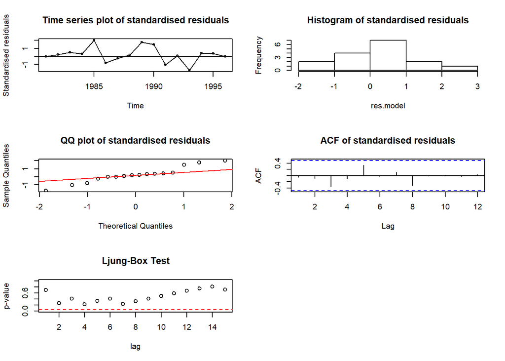

## Forecasting

The forecasting using ARIMA(0,1,1) model of eggs depositions series are shown below.

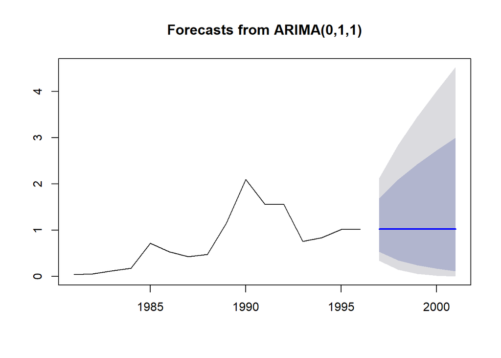

```r
fit = Arima(eggsdata,c(0,1,1), lambda = .45)
plot(forecast(fit,h=5))
```

# Conclusion

The tendency of the eggs depositions series in the next five years is uncertain or most probably remains steady.

# Appendix

## Function

- Sorting AIC and BIC values:  
  sort.score <- function(x, score = c(“bic”, “aic”)){ if (score == “aic”){ x[with(x, order(AIC)),] } else if (score == “bic”) { x[with(x, order(BIC)),] } else { warning(‘score = “x” only accepts valid arguments (“aic”,“bic”)’) } }
- Residual Analysis:  
  residual.analysis <- function(model, std = TRUE){ library(TSA) library(FitAR) if (std == TRUE){ res.model = rstandard(model) }else{ res.model = residuals(model) } par(mfrow=c(3,2)) plot(res.model,type=‘o’,ylab=‘Standardised residuals’, main=“Time series plot of standardised residuals”) abline(h=0) hist(res.model,main=“Histogram of standardised residuals”) qqnorm(res.model,main=“QQ plot of standardised residuals”) qqline(res.model, col = 2) acf(res.model,main=“ACF of standardised residuals”) print(shapiro.test(res.model)) k=0 LBQPlot(res.model, lag.max = length(model$residuals)-1 , StartLag = k + 1, k = 0, SquaredQ = FALSE) par(mfrow=c(1,1)) }